# Assignment 14

Robert Wilbrand

27.02.2021

```r
library(raster)
library(tidyverse)
library(sf)
library(gstat)
theme_set(theme_minimal())
knitr::opts_knit$set(root.dir = "C:/MSc GCG/QM/Data/data")
knitr::opts_chunk$set(message = FALSE, warning = FALSE)
options(scipen = 8)
```

## Climate station data for Germany

For this exercise we will use long-term average climate station data from the German Meteorological Service (DWD). Monthly and yearly average precipitation (mm) data are available for the period 1981 and 2010.

http://www.dwd.de/DE/leistungen/klimadatendeutschland/langj_mittelwerte.html

ftp://ftp-cdc.dwd.de/pub/CDC/

In this exercise, you are asked to create precipitation maps for the state of Brandenburg from weather station data using two different methods: 1) inverse distance weighted interpolation, and 2) ordinary kriging. Plot and compare the results/maps and semi-variograms.

### 1. Create a SpatialPointsDataFrame.

Create a SpatialPointsDataFrame from the precipitation dataset `"nieder_1981-2010_aktStandort.csv"`. The precipitation dataset contains longitude (column `x`) and latitude (column `y`). The coordinate reference system is geographic WGS-84 (EPSG code 4326). In proj4 format this can be written as `"+init=epsg:4326"`. To analyze spatial distances you need to transform this dataset to an equal area projection, e.g. `"+init=epsg:3035"`. Note, use only the station data from Brandenburg (see `state` column).

```r
# read in data
precip <- read_csv("nieder_1981-2010_aktStandort.csv")

# create Brandenburg mask
bundesland <- readRDS("gadm36_DEU_1_sf.rds")
brandenburg_outline <- bundesland %>%
  filter(NAME_1 == "Brandenburg") %>%
  st_transform(3035)

# subset data, define as spatial and transform to appropriate CRS
brandenburg_sf <- precip %>%
  filter(state == "Brandenburg") %>%
  st_as_sf(coords = c("x","y")) %>%
  st_set_crs(4326) %>%
  st_transform(3035)

# create regular grid for interpolation, intersect with spatial mask
bb_grid <- st_make_grid(brandenburg_sf,
                        n = c(100,100),
                        what = "centers") %>%
  st_intersection(brandenburg_outline)
```

### 2. Create a map of annual precipitation (column `year`) using Inverse Distance Weighted Interpolation.

```r
# perform IDW interpolation with power=2
bb.idw <- idw(year ~ 1, brandenburg_sf, bb_grid, idp = 2)
```

```
## [inverse distance weighted interpolation]
```

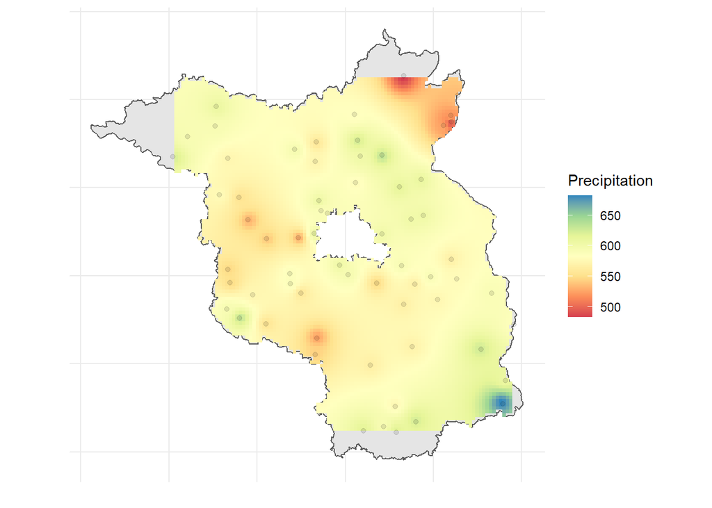

```r
# create template raster and rasterize interpolation results
bb.tmp <- raster(bb.idw, ncol = 100, nrow = 100)
bb.ras <- rasterize(bb.idw, bb.tmp, "var1.pred")

# reset to tibble for easy plotting
bb.tbb <- bb.ras %>% as.data.frame(xy=T) %>% as_tibble

# plot results
ggplot() +
  geom_sf(data = brandenburg_outline) +
  geom_raster(data = bb.tbb, aes(x, y, fill = layer)) +
  scale_fill_distiller(palette = "Spectral",
                       na.value = NA,
                       direction = 1) +
  geom_sf(data = brandenburg_sf, alpha = 0.1) +
  labs(x="",y="", fill = "Precipitation") +
  coord_sf(label_axes = "----",
           datum = st_crs(3035))
```

### 3. Create a map of annual precipitation (column `year`) using ordinary kriging with constant intercept.

```r
# create empirical variogram
bbv <- variogram(year ~ 1, brandenburg_sf)

# fit theoretical variogram
bb.vfit <- fit.variogram(bbv, vgm(1100, "Sph", 45000, 1))

# show variogram parameters and plots
bb.vfit
```

```
##   model     psill    range
## 1   Nug  126.9571     0.00
## 2   Sph 1014.8613 71591.35
```

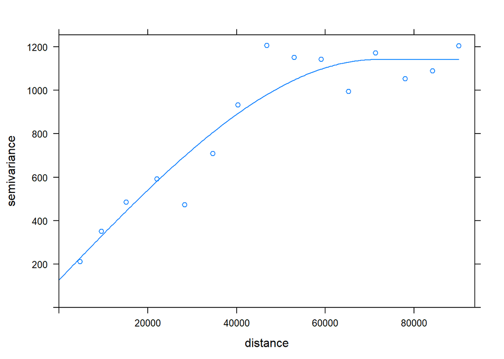

```r
plot(bbv, bb.vfit)
```

```r
# perform ordinary kriging
bb.ok <- krige(year ~ 1, brandenburg_sf, bb_grid, bb.vfit)
```

```
## [using ordinary kriging]
```

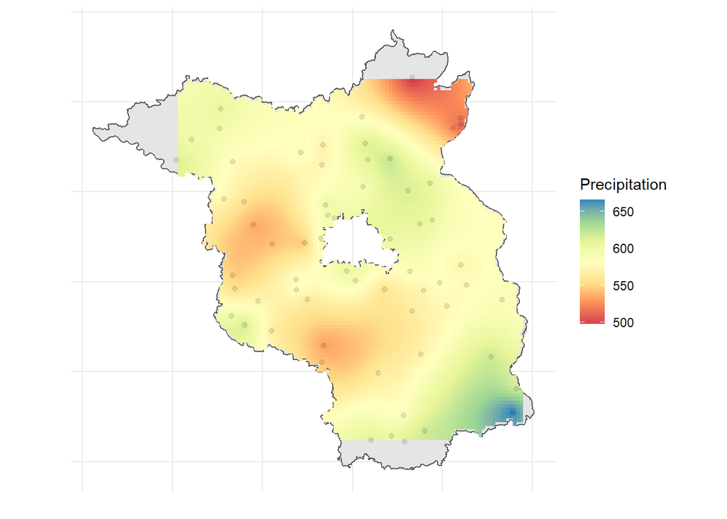

```r
# rasterize (with previously created template)
bb.ras2 <- rasterize(bb.ok, bb.tmp)

# reset to tibble for easy plotting
bb.tbb2 <- bb.ras2 %>% as.data.frame(xy=T) %>% as_tibble

# plot results
ggplot() +
  geom_sf(data = brandenburg_outline) +
  geom_raster(data = bb.tbb2, aes(x, y, fill = var1.pred)) +
  scale_fill_distiller(palette = "Spectral",
                       na.value = NA,
                       direction = 1) +
  geom_sf(data = brandenburg_sf, alpha = 0.1) +
  labs(x="",y="", fill = "Precipitation") +
  coord_sf(label_axes = "----",
           datum = st_crs(3035))
```